# wk9-3_데이터마이닝과 분류

choi

2020 11 12

# 분류

- 분류분석 (classification analysis)은 다수의 속성 (attribute, variable)을 갖는 객체 (object)를 그룹 또는 범주 (class, category) 로 분류
- 학습표본 (training sample)으로부터 효율적인(오분류율 최소화 (cost function을 최소화)) 분류규칙 (classification rule)을 생성.

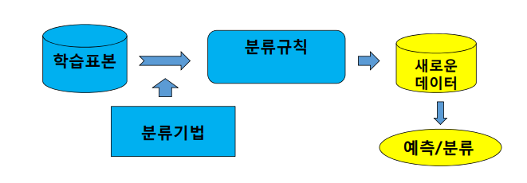

# 분류 (Classification) - 분류규칙 - 이동통신회사 선호도 조사 (n=9), 타겟변수(선호통신사)=A, B

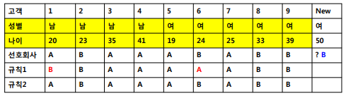

- Y=(A, B) - 범주가 2개인 분류문제, 속성 변수 2개 (성별, 나이) -위의 학습표본으로부터 다음과 같은 분류규칙을 얻었다고 가정하자.

```
(분류 규칙 1) 남자이고 Age≥30 or 여자이고 Age≤30 =>범주 1 (A)
그 밖의 경우이면 => 범주 2 (B)
```

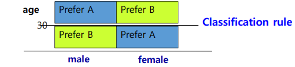

# 분류 – 오분류율(Misclassification rate) - 오분류율(misclassification rate) = 오분류 객체수/전체 객체수 = 2/9=0.22

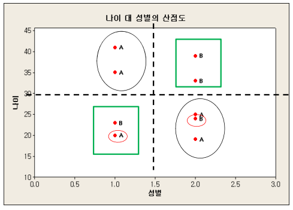

# 분류 – 과적합(overfitting) 앞의 분류문제에 대해서 (분류규칙 2)

[output not shown]

(분류규칙 2) 에 따르면 오분류율 0/9=0 이 된다. 학습표본에 대해서 오분류율을 0으로 인위적으로 만드 는 경우 과적합 (overfitting)이라고 한다

과적합 (overfitting) - 분류모형에서 훈련데이터에 대한 과적합을 시킬 경우, 실제 데이터를 적용했을때 더 높은 오분류율 발생

# 분류 – 과적합(overfitting)

- 예측모형에서의 과적합

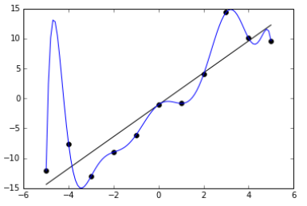

예측모형에서 훈련데이터에 대한 과한 적합모델을 선택하 는 경우, 실제 데이터를 적용했을때 더 높은 오차를 발생 ->

이런 과적합문제를 방지하기 위하여 학습데이터와 검증데이터를 5:5. 6:4, 7:3, 8:2 로 분리하여 모형의 성능을 비교평가한다 # 분류- 교차검증(cross-validation) - 분류모형의 유효성 검증방법

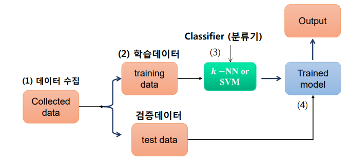

# 분류- 교차검증(cross-validation)

- k-fold cross validation method 교차타당성 검증

5-fold cross-validation의 예제 : n=100 이면 5등분으로 나누어 4등분은 학습데이터로 예측 모형을 구성하고, 나머지 5등분째 데이터로 검증한다

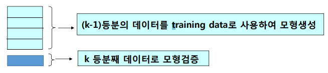